# Assignment for Week Two

Data and Computing Fundamentals

Macalester College

### Simple Plotting

Use the `mScatter()` function to generate a graphic, as follows:

```r
data( NHANES )
Small <- sample_n( NHANES, size=1000 ) # for faster plotting
```

```r
DCF::mScatter( Small )
```

Set up the mapping from variables to graphical attributes like this:

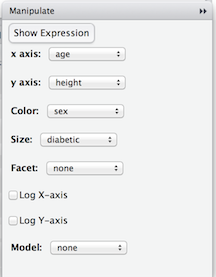

Attributes set using `DCF::mScatter()`

Once you have made the plot, describe briefly the meaning, in everyday human terms, of the pattern displayed in the scatterplot. (You can find the definitions of the variables using `help( NHANES )`.)

Include an R chunk in your write-up that generates the graph.

### Make this Plot

Using the data in `Small`, make this plot with `DCF::mScatter()`:

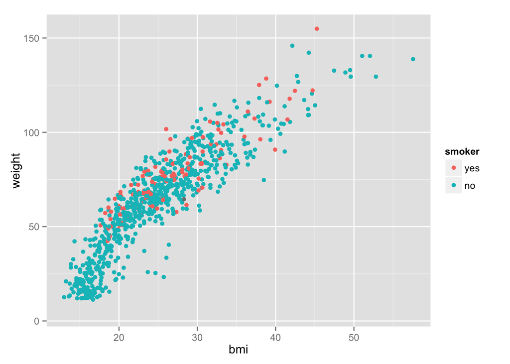

Write down the mapping between variables and graphical attributes.

### Counting Votes

Using the `Minneapolis2013` data table, answer these questions:

1. How many cases are there?
2. Who were the top 5 candidates in the `Second` vote selections.
3. How many ballots are marked “undervote” in
   - `First` choice selections?
   - `Second` choice selections?
   - `Third` choice selections?
4. What are the top 3 combinations of `First` and `Second` vote selections? (That is, of all the possible ways a voter might have marked his or her first and second choices, which received the highest number of votes?)
5. Which `Precinct` had the highest number of ballots cast?

### Zip Codes

Using the `ZipGeography` data

Find the total land area and population in each state.

- Make a scatter plot showing the relationship between land area and population for each state.
- Make a [choropleth map](http://en.wikipedia.org/wiki/Choropleth_map) showing the population of each state.
- Make a choropleth map showing the population per unit area of each state.

Using the `ZipDemography` data

- Make a scatter plot showing the relationship, if any, between the number of `Foreignborn` people in a zip code and the number who `SpeakalanguageotherthanEnglishathome5yearsandover`.

Explain what would keep you, at this point, from calculating the fraction of people in each state who have a `Bachelorsdegreeorhigher`. Say how you would go about constructing such a plot — but don’t actually do it! Too much work.